# Prediction Analysis (Logistic Regression)

#### Var 32: Roundtrip rate of a Customer

- *Description* : The number of RT cases associated to a customer in the past; based on the recency of the case the RT counts have been assigned weights. For eg: A case(with 8 RTs) raised in the FY16Q4 will have RT count as 8 but A case(with 8 RTs) raised in the FY15Q4 will have 8*4/8 i.e. 4 RT count
- *Hypothesis* : There is a higher risk of cases having Avoidable RMA when rt_cases_cust is high
- *Findings* :

##### Missing value check & Bi variate analysis

```
True     227805
False     16489
Name: rt_cases_cust, dtype: int64
```

```
Top 20 rt_cases_cust by %avoidability
arma  rt_cases_cust  Total_cases   % Cases  %avoidability
0             5.500           21  0.008596           33.3
1             5.875           37  0.015146           27.0
2             8.125           58  0.023742           24.1
3            18.625          302  0.123622           21.2
4           180.375         2475  1.013124           20.7
5             3.000          258  0.105610           19.8
6             6.750          323  0.132218           19.2
7             7.750          158  0.064676           18.4
8             7.875           85  0.034794           17.6
9             7.125          525  0.214905           16.8
10            6.000          103  0.042162           16.5
11           18.750          598  0.244787           16.1
12            1.875         1410  0.577173           15.7
13           25.750         1558  0.637756           15.7
14            6.125          587  0.240284           15.5
15           20.000          391  0.160053           15.1
16            9.875          398  0.162918           14.8
17            5.125          218  0.089237           14.7
18           16.125          404  0.165375           14.4
19            0.250         3392  1.388491           14.3
```

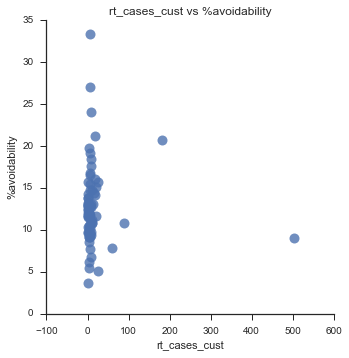

```python
display(df['rt_cases_cust'].notnull().value_counts())
print ('Top 20 rt_cases_cust by %avoidability')
variablec.Bivariate2('rt_cases_cust')
variablec.Graph('rt_cases_cust')
```

#### Var 33: Roundtrip rate of a PID

- *Description* : The number of RT cases associated to a PID in the past; based on the recency of the case the RT counts have been assigned weights. For eg: A case(with 8 RTs) raised in the FY16Q4 will have RT count as 8 but A case(with 8 RTs) raised in the FY15Q4 will have 8*4/8 i.e. 4 RT count
- *Hypothesis* : There is a higher risk of cases having Avoidable RMA when rt_cases_pid is high
- *Findings* :

##### Missing value check & Bi variate analysis

```
True     212597
False     31697
Name: rt_cases_pid, dtype: int64
```

```
Top 20 ntf_cases_pid by %avoidability
arma  rt_cases_pid  Total_cases   % Cases  %avoidability
0            9.375          104  0.042572           26.9
1            7.250           45  0.018420           26.7
2           11.750          128  0.052396           25.0
3           21.375          291  0.119119           21.0
4           15.250          150  0.061401           19.3
5           10.625          169  0.069179           18.3
6           16.750          320  0.130990           18.1
7           15.500          374  0.153094           17.6
8            8.250           88  0.036022           17.0
9           10.500          168  0.068770           16.7
10          17.625          243  0.099470           16.5
11          20.375          233  0.095377           16.3
12           9.750          104  0.042572           15.4
13          48.000         1251  0.512088           15.2
14         243.000         3328  1.362293           15.0
15          56.000          960  0.392969           15.0
16          33.625          971  0.397472           14.8
17           3.500          250  0.102336           14.8
18           6.750          123  0.050349           14.6
19          13.375          862  0.352854           14.3
```

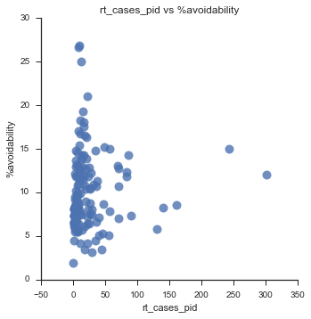

```python
display(df['rt_cases_pid'].notnull().value_counts())
print ('Top 20 ntf_cases_pid by %avoidability')
variablec.Bivariate2('rt_cases_pid')
variablec.Graph('rt_cases_pid')
```

#### Var 34: Cases Raised by a Customer

- *Description* : The number of cases associated to a customer in the past.Based on the recency of the case,it has been assigned weights. For eg: A case raised in the FY16Q4 will have be counted as 1 but A case raised in the FY15Q4 will have 4/8 as the count
- *Hypothesis* : There is a higher risk of cases having Avoidable RMA when sr_raised_cust is high
- *Findings* :

##### Missing value check & Bi variate analysis

```
True     227805
False     16489
Name: sr_raised_cust, dtype: int64
```

```
Top 20 sr_raised_cust by %avoidability
arma  sr_raised_cust  Total_cases   % Cases  %avoidability
0             65.375          101  0.041344           28.7
1             40.750           52  0.021286           23.1
2            229.250          302  0.123622           21.2
3           1493.500         2475  1.013124           20.7
4             37.250           45  0.018420           20.0
5             49.000           82  0.033566           19.5
6             50.625           78  0.031929           19.2
7             61.875          111  0.045437           18.0
8             75.625           85  0.034794           17.6
9             68.125          162  0.066314           17.3
10            36.000           41  0.016783           17.1
11            61.000          105  0.042981           17.1
12            70.000          121  0.049530           16.5
13            67.250          103  0.042162           16.5
14           323.750          598  0.244787           16.1
15           463.875         1558  0.637756           15.7
16           106.875          161  0.065904           15.5
17            82.125          136  0.055671           15.4
18            41.750           33  0.013508           15.2
19            49.875           92  0.037660           15.2
```

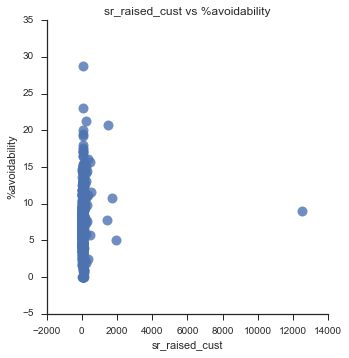

```python
display(df['sr_raised_cust'].notnull().value_counts())
print ('Top 20 sr_raised_cust by %avoidability')
variablec.Bivariate2('sr_raised_cust')
variablec.Graph('sr_raised_cust')
```

#### Var 35: Cases raised for a PID

- *Description* : The number of cases associated to a PID in the past; based on the recency of the case,it has been assigned weights. For eg: A case raised in the FY16Q4 will have be counted as 1 but A case raised in the FY15Q4 will wil have 4/8 as the count
- *Hypothesis* : There is a higher risk of cases having Avoidable RMA when sr_raised_pid is high
- *Findings* :

##### Missing value check & Bi variate analysis

```
True     212597
False     31697
Name: sr_raised_pid, dtype: int64
```

```
Top 20 sr_raised_pid by %avoidability
arma  sr_raised_pid  Total_cases   % Cases  %avoidability
0            68.625          104  0.042572           26.9
1            89.500          128  0.052396           25.0
2            34.375           28  0.011462           21.4
3            23.875           33  0.013508           21.2
4            51.875           48  0.019648           20.8
5            65.875           81  0.033157           19.8
6            37.375           66  0.027017           19.7
7           124.125          150  0.061401           19.3
8            47.750          121  0.049530           19.0
9            50.500           65  0.026607           18.5
10            7.375           49  0.020058           18.4
11          165.500          320  0.130990           18.1
12          196.250          374  0.153094           17.6
13          150.250          221  0.090465           17.2
14           79.000           88  0.036022           17.0
15          135.250          168  0.068770           16.7
16           29.000          103  0.042162           16.5
17          172.250          243  0.099470           16.5
18           82.125          141  0.057717           16.3
19           51.625          137  0.056080           16.1
```

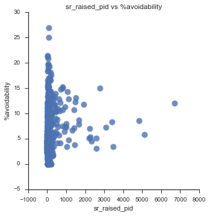

```python
display(df['sr_raised_pid'].notnull().value_counts())
print ('Top 20 sr_raised_pid by %avoidability')
variablec.Bivariate2('sr_raised_pid')
variablec.Graph('sr_raised_pid')
```

#### Var 36: #Bugs asssociated to a PID

- *Description* : The number of bugs associated to a pid
- *Hypothesis* : There is a higher risk of cases having Avoidable RMA when the 'bugs_pid' is high
- *Findings* :

##### Missing value check & Bi variate analysis

```
True     212608
False     31686
Name: bugs_pid, dtype: int64
```

```
Top 20 bugs_pid by %avoidability
arma  bugs_pid  Total_cases   % Cases  %avoidability
0         27.0          294  0.120347           18.4
1         33.0          233  0.095377           16.3
2         74.0         1251  0.512088           15.2
3         63.0          960  0.392969           15.0
4        355.0         3328  1.362293           15.0
5         39.0          283  0.115844           14.1
6         47.0          850  0.347941           13.9
7        153.0         2595  1.062245           13.1
8        132.0         1921  0.786348           12.8
9        147.0         1795  0.734770           12.3
10        95.0         1280  0.523959           12.2
11       651.0        11282  4.618206           12.0
12       103.0         1711  0.700386           11.9
13       204.0         3316  1.357381           11.8
14        60.0          618  0.252974           11.8
15        67.0         1332  0.545245           11.6
16        98.0         1717  0.702842           11.6
17        81.0         1783  0.729858           11.3
18        43.0          977  0.399928           11.0
19        85.0          865  0.354082           10.8
```

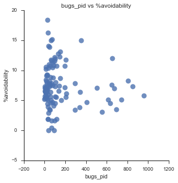

```python
display(df['bugs_pid'].notnull().value_counts())
print ('Top 20 bugs_pid by %avoidability')
variablec.Bivariate2('bugs_pid')
variablec.Graph('bugs_pid')
```

```python
var = variable.Getvariables()
dat = variablec.Getdata()
varc = variablec.Getvariables()
```

### Model

```python
class modelrun():
    def __init__(self,data,var,varc):
        self.data = data
        self.variables = var.copy()
        self.variablesc = varc.copy()
        self.variablesc.append('arma')

    def createdummycolumns(self):
        self.moddata = self.data.copy()
        for var in self.variables:
            dummy_ranks = pd.get_dummies(self.data[var],prefix = var)
            self.moddata = self.moddata[self.variablesc].join(dummy_ranks.ix[:, : -1])
            self.variablesc = self.moddata.columns.values

    def createtestdummycolumns(self):
        self.moddata = self.data.copy()
        for var in self.variables:
            dummy_ranks = pd.get_dummies(self.data[var],prefix = var)
            self.moddata = self.moddata[self.variablesc].join(dummy_ranks)
            self.variablesc = self.moddata.columns.values

    def gettrainingcols(self):
        return self.train_cols


    def subsetdata(self):
        #self.moddata = self.moddata.fillna(0)
        self.train_cols = [col for col in self.moddata.columns if col not in ['arma','sr_to_ldos',
        'bug_cnt','ntf_cases_cust','ntf_cases_pid','rt_cases_cust','bugs_pid','entry_channel_AUTOMATIC','entry_channel_PHONE',
        'request_type_Diagnose and Fix my Problem','entitlement_type_Expedited Same Day Delivery and FE',
        'entitlement_type_Licensing Registration Completed by Agent','entitlement_type_RMA service level associated with the product\'s warranty',
        'Customer_name_Customer_name_level0','Customer_name_Customer_name_level4','Customer_name_Customer_name_level7',
        'Customer_name_Customer_name_level8','customer_vertical_customer_vertical_level0','customer_vertical_customer_vertical_level1',
        'customer_vertical_customer_vertical_level2','customer_market_segment_COM','customer_market_segment_ENT',
        'customer_market_segment_UNKNOWN','country_country_level0','country_country_level1','country_country_level3',
        'country_country_level4','country_country_level5','contract_type_contract_type_level0','contract_type_contract_type_level1',
        'contract_type_contract_type_level10','contract_type_contract_type_level2','contract_type_contract_type_level3',
        'contract_type_contract_type_level4','contract_type_contract_type_level5','contract_type_contract_type_level6',
        'contract_type_contract_type_level7','product_family_UCSB','product_family_UCSM','product_family_UCSME','product_family_UCSV',
        'product_family_UCSW','product_type_ACCESSORY','product_type_BASE','product_type_SWSUBSCRIP','sr_pid_sr_pid_level0',
        'sr_pid_sr_pid_level7','sr_pid_sr_pid_level8','complexity_Unknown','creator_workgroup_name_creator_workgroup_name_level0',
        'incident_urgency_0','incident_urgency_B2B Transferred To Partner','incident_urgency_Not Escalated',
        'incident_urgency_Queue to Backbone - Customer Requested Escalation','incident_urgency_Queue to Backbone - Escalated to CAPS',
        'incident_urgency_SS Transfer from TAC to SSTG','customer_activity_code_CONFIG','customer_activity_code_INSTALL',
        'customer_activity_code_UPGRADE','entry_channel_EMAIL','initial_problem_code_HARDWARE_FAILURE','Customer_name_Customer_name_level6',
        'Customer_name_Customer_name_level6','initial_problem_code_SOFTWARE_FAILURE','incident_urgency_NONE','initial_problem_code_DATA_CORRUPTION',
        'Customer_name_Customer_name_level5','Customer_name_Customer_name_level3','Customer_name_Customer_name_level2','sr_pid_sr_pid_level3',
        'complexity_0','creator_workgroup_name_creator_workgroup_name_level2','max_severity','country_country_level2','country_country_level2',
        'incident_urgency_B2B Escalated','creator_workgroup_name_creator_workgroup_name_level7','creator_workgroup_name_creator_workgroup_name_level8',
        'product_type_CHASSIS','product_type_POWER','creator_workgroup_name_creator_workgroup_name_level1','product_type_SWITCH','sr_pid_sr_pid_level1'
                                                           ,'initial_severity_3']]

    def run(self):
        logit = sm.Logit(self.moddata['arma'], self.moddata[self.train_cols])
        self.result = logit.fit_regularized(method = 'l1')
        return self.result

    def PredictTest(self,result,train_cols):
        self.moddata = self.moddata.reset_index()
        for col in train_cols:
            if col not in self.moddata.columns:
                self.moddata[col] = 0
        predicted = result.predict(self.moddata[train_cols])
        return predicted

    def kcross(self):
        count = 0
        kf = KFold(244294,n_folds = 10)
        self.moddata = self.moddata.reset_index()
        for train_index,test_index in kf:
            logit = sm.Logit(self.moddata['arma'].ix[train_index.tolist()], self.moddata[self.train_cols].ix[train_index.tolist()])
            result = logit.fit_regularized(method = 'l1')
            predicted = result.predict(self.moddata[self.train_cols].ix[test_index.tolist()])
            actual = self.moddata['arma'].ix[test_index.tolist()]
            pa = pd.DataFrame(list(predicted),list(actual)).reset_index()
            pa = pa.rename(columns = {'index' : 'Actual', 0 : 'Probability'})
            pa['Predicted'] = np.where(pa['Probability'] >= 0.1,1,0)
            pa = pa.astype('int64')
            C = confusion_matrix(pa['Actual'], pa['Predicted'])
            count = count + 1
            assert C.shape == (2,2), "Confusion matrix should be from binary classification only."
            tn = C[0,0]; fp = C[0,1]; fn = C[1,0]; tp = C[1,1];
            self.pred=pd.DataFrame()
            PreValue = round(((tp)/(tp+fn))*100,2)
            ActValue = round((tp+tn)/(fp+tn+tp+fn)*100,2)
            display("Iteration " + str(count) + " : ")
            display("Positive Prediction" + " : " + str(PreValue) + " %")
            display("Actual Prediction" + " : " + str(ActValue) +  " %")
            self.show_confusion_matrix(C)

    def show_confusion_matrix(self,C,class_labels=['0','1']):
        assert C.shape == (2,2), "Confusion matrix should be from binary classification only."
        # true negative, false positive, etc...
        tn = C[0,0]; fp = C[0,1]; fn = C[1,0]; tp = C[1,1];
        NP = fn+tp # Num positive examples
        NN = tn+fp # Num negative examples
        N  = NP+NN
        fig = plt.figure(figsize=(8,8))
        ax  = fig.add_subplot(111)
        ax.imshow(C, interpolation='nearest', cmap=plt.cm.gray)

        # Draw the grid boxes
        ax.set_xlim(-0.5,2.5)
        ax.set_ylim(2.5,-0.5)
        ax.plot([-0.5,2.5],[0.5,0.5], '-k', lw=2)
        ax.plot([-0.5,2.5],[1.5,1.5], '-k', lw=2)
        ax.plot([0.5,0.5],[-0.5,2.5], '-k', lw=2)
        ax.plot([1.5,1.5],[-0.5,2.5], '-k', lw=2)

        # Set xlabels
        ax.set_xlabel('Predicted Label', fontsize=16)
        ax.set_xticks([0,1,2])
        ax.set_xticklabels(class_labels + [''])
        ax.xaxis.set_label_position('top')
        ax.xaxis.tick_top()
        # These coordinate might require some tinkering. Ditto for y, below.
        ax.xaxis.set_label_coords(0.34,1.06)

        # Set ylabels
        ax.set_ylabel('True Label', fontsize=16, rotation=90)
        ax.set_yticklabels(class_labels + [''],rotation=90)
        ax.set_yticks([0,1,2])
        ax.yaxis.set_label_coords(-0.09,0.65)

        # Fill in initial metrics: tp, tn, etc...
        ax.text(0,0,'True Neg: %d\n(Num Neg: %d)'%(tn,NN),va='center',ha='center',bbox=dict(fc='w',boxstyle='round,pad=1'))
        ax.text(0,1,'False Neg: %d'%fn,va='center',ha='center',bbox=dict(fc='w',boxstyle='round,pad=1'))
        ax.text(1,0,'False Pos: %d'%fp,va='center',ha='center',bbox=dict(fc='w',boxstyle='round,pad=1'))
        ax.text(1,1,'True Pos: %d\n(Num Pos: %d)'%(tp,NP),va='center',ha='center',bbox=dict(fc='w',boxstyle='round,pad=1'))
        # Fill in secondary metrics: accuracy, true pos rate, etc...
        ax.text(2,0,'False Pos Rate: %.2f'%(fp / (fp+tn+0.)),va='center',ha='center',bbox=dict(fc='w',boxstyle='round,pad=1'))
        ax.text(2,1,'True Pos Rate: %.2f'%(tp / (tp+fn+0.)),va='center',ha='center',bbox=dict(fc='w',boxstyle='round,pad=1'))
        ax.text(2,2,'Accuracy: %.2f'%((tp+tn+0.)/N),va='center',ha='center',bbox=dict(fc='w',boxstyle='round,pad=1'))
        ax.text(0,2,'Neg Pre Val: %.2f'%(1-fn/(fn+tn+0.)),va='center',ha='center',bbox=dict(fc='w',boxstyle='round,pad=1'))
        ax.text(1,2,'Pos Pred Val: %.2f'%(tp/(tp+fn+0.)),va='center',ha='center',bbox=dict(fc='w',boxstyle='round,pad=1'))
        plt.tight_layout()
        plt.show()

        #print the postive prediction and actual prediction
        self.pred=pd.DataFrame()
        self.pred['Positive Prediction'] = tp/(fp+fn)
        self.pred['Actual Prediction'] = (tp+fn)/(fp+tn+tp+fn)
        return(self.pred)

    def getprob(self):
        logit = sm.Logit(self.moddata['arma'], self.moddata[self.train_cols])
        result = logit.fit_regularized(method = 'l1')
        probability=result.predict(self.moddata[self.train_cols])
        pr = pd.DataFrame()
        pr['probability']=list(probability)
        pr['incident_number']=self.data['incident_number']
        pr['arma']=self.data['arma']
        pr = pr.sort_values(by = 'probability' ,axis = 0).reset_index()
        return pr

    def getROC(self):
        count = 0
        kf = KFold(244294,n_folds = 10)
        self.moddata = self.moddata.reset_index()
        for train_index,test_index in kf:
            logit = sm.Logit(self.moddata['arma'].ix[train_index.tolist()], self.moddata[self.train_cols].ix[train_index.tolist()])
            result = logit.fit_regularized(method = 'l1')
            predicted = result.predict(self.moddata[self.train_cols].ix[test_index.tolist()])
            actual = self.moddata['arma'].ix[test_index.tolist()]
            pa = pd.DataFrame(list(predicted),list(actual)).reset_index()
            pa = pa.rename(columns = {'index' : 'Actual', 0 : 'Probability'})
            return pa
```

```python
mode = modelrun(dat,var,varc)
mode.createdummycolumns()
mode.subsetdata()
columns = mode.gettrainingcols()
```

### Running the model

```python
result = mode.run()
```

```
Optimization terminated successfully.    (Exit mode 0)
            Current function value: 0.154447748978
            Iterations: 493
            Function evaluations: 517
            Gradient evaluations: 493
```

### Output Summary

```python
result.summary()
```

Logit Regression Results

| Dep. Variable: | arma | No. Observations: | 244294 |
| --- | --- | --- | --- |
| Model: | Logit | Df Residuals: | 244225 |
| Method: | MLE | Df Model: | 68 |
| Date: | Wed, 07 Sep 2016 | Pseudo R-squ.: | 0.4237 |
| Time: | 19:54:51 | Log-Likelihood: | -37731. |
| converged: | True | LL-Null: | -65472. |
|  |  | LLR p-value: | 0.000 |

|  | coef | std err | z | P>\|z\| | [95.0% Conf. Int.] |
| --- | --- | --- | --- | --- | --- |
| engineer_cnt | 0.5260 | 0.027 | 19.152 | 0.000 | 0.472 0.580 |
| wg_cnt | 0.8834 | 0.034 | 26.277 | 0.000 | 0.818 0.949 |
| pc_cnt | -0.3158 | 0.029 | -10.751 | 0.000 | -0.373 -0.258 |
| rc_cnt | -0.7596 | 0.079 | -9.584 | 0.000 | -0.915 -0.604 |
| misqueue_cnt | 0.1792 | 0.005 | 34.534 | 0.000 | 0.169 0.189 |
| sr_reopened_cnt | 1.1391 | 0.047 | 24.187 | 0.000 | 1.047 1.231 |
| rma_rate_cust | -0.0010 | 0.000 | -9.055 | 0.000 | -0.001 -0.001 |
| rma_rate_pid | -0.0004 | 4.03e-05 | -9.560 | 0.000 | -0.000 -0.000 |
| rt_cases_pid | 0.0018 | 0.000 | 3.808 | 0.000 | 0.001 0.003 |
| sr_raised_cust | 0.0005 | 5.59e-05 | 8.914 | 0.000 | 0.000 0.001 |
| sr_raised_pid | 0.0002 | 2.19e-05 | 7.121 | 0.000 | 0.000 0.000 |
| initial_severity_1 | 0.1971 | 0.059 | 3.336 | 0.001 | 0.081 0.313 |
| initial_severity_2 | 0.0978 | 0.045 | 2.187 | 0.029 | 0.010 0.186 |
| initial_problem_code_CONFIG_ASSISTANCE | -0.4526 | 0.038 | -11.782 | 0.000 | -0.528 -0.377 |
| initial_problem_code_ERROR_MESSAGES | -0.1721 | 0.030 | -5.801 | 0.000 | -0.230 -0.114 |
| initial_problem_code_HARDWARE_DOA | 0.3833 | 0.139 | 2.752 | 0.006 | 0.110 0.656 |
| initial_problem_code_INSTLL_UNSTLL_UPGRD | -0.5730 | 0.126 | -4.538 | 0.000 | -0.820 -0.326 |
| initial_problem_code_INTEROP | -0.4187 | 0.063 | -6.645 | 0.000 | -0.542 -0.295 |
| initial_problem_code_LICENSING | -3.5627 | 0.530 | -6.721 | 0.000 | -4.602 -2.524 |
| initial_problem_code_PASSWORD_RECOV | -1.6859 | 0.900 | -1.874 | 0.061 | -3.449 0.077 |
| initial_problem_code_PRODUCT_QUESTION | -1.4159 | 0.452 | -3.133 | 0.002 | -2.302 -0.530 |
| initial_problem_code_SOFTWARE_ASSISTANCE | -1.3482 | 0.401 | -3.366 | 0.001 | -2.133 -0.563 |
| request_type_Answer my Question | -0.9690 | 0.179 | -5.419 | 0.000 | -1.319 -0.619 |
| request_type_Replace my Product | 0.0706 | 0.024 | 2.898 | 0.004 | 0.023 0.118 |
| entitlement_type_Field Engineer | -1.1375 | 0.117 | -9.753 | 0.000 | -1.366 -0.909 |
| Customer_name_Customer_name_level1 | 0.9962 | 0.513 | 1.942 | 0.052 | -0.009 2.002 |
| Customer_name_Customer_name_level10 | -1.0317 | 0.153 | -6.724 | 0.000 | -1.332 -0.731 |
| Customer_name_Customer_name_level11 | -1.0673 | 0.082 | -13.055 | 0.000 | -1.228 -0.907 |
| Customer_name_Customer_name_level12 | -1.1316 | 0.048 | -23.425 | 0.000 | -1.226 -1.037 |
| Customer_name_Customer_name_level13 | -1.4956 | 0.046 | -32.560 | 0.000 | -1.586 -1.406 |
| Customer_name_Customer_name_level14 | -1.6788 | 0.040 | -42.036 | 0.000 | -1.757 -1.600 |
| Customer_name_Customer_name_level15 | -2.0116 | 0.038 | -53.297 | 0.000 | -2.086 -1.938 |
| Customer_name_Customer_name_level16 | -2.3504 | 0.038 | -62.234 | 0.000 | -2.424 -2.276 |
| Customer_name_Customer_name_level17 | -4.8961 | 0.055 | -88.893 | 0.000 | -5.004 -4.788 |
| customer_market_segment_SP | -0.1029 | 0.030 | -3.473 | 0.001 | -0.161 -0.045 |
| country_country_level6 | 1.3138 | 0.559 | 2.350 | 0.019 | 0.218 2.410 |
| country_country_level7 | -0.3964 | 0.075 | -5.292 | 0.000 | -0.543 -0.250 |
| country_country_level8 | -0.3308 | 0.059 | -5.606 | 0.000 | -0.446 -0.215 |
| contract_type_contract_type_level11 | -0.4695 | 0.075 | -6.275 | 0.000 | -0.616 -0.323 |
| contract_type_contract_type_level8 | -0.4546 | 0.110 | -4.132 | 0.000 | -0.670 -0.239 |
| product_family_UCS | -0.3896 | 0.053 | -7.306 | 0.000 | -0.494 -0.285 |
| product_family_UCSC | -0.1185 | 0.025 | -4.793 | 0.000 | -0.167 -0.070 |
| product_type_ASSEMBLY | 0.1222 | 0.057 | 2.131 | 0.033 | 0.010 0.235 |
| product_type_BOARD | 0.4473 | 0.076 | 5.924 | 0.000 | 0.299 0.595 |
| product_type_CABLE | 0.6772 | 0.317 | 2.138 | 0.033 | 0.056 1.298 |
| product_type_DEVICES | 0.1102 | 0.049 | 2.257 | 0.024 | 0.014 0.206 |
| product_type_FUNCSYSTM | 0.1520 | 0.056 | 2.736 | 0.006 | 0.043 0.261 |
| product_type_MEMORY | 0.4563 | 0.070 | 6.512 | 0.000 | 0.319 0.594 |
| product_type_SERVER | 0.3060 | 0.030 | 10.263 | 0.000 | 0.248 0.364 |
| sr_pid_sr_pid_level10 | -0.4486 | 0.057 | -7.856 | 0.000 | -0.561 -0.337 |
| sr_pid_sr_pid_level11 | -0.5533 | 0.053 | -10.384 | 0.000 | -0.658 -0.449 |
| sr_pid_sr_pid_level12 | -0.7299 | 0.054 | -13.604 | 0.000 | -0.835 -0.625 |
| sr_pid_sr_pid_level13 | -1.1710 | 0.062 | -18.872 | 0.000 | -1.293 -1.049 |
| sr_pid_sr_pid_level2 | 1.5969 | 0.266 | 6.001 | 0.000 | 1.075 2.118 |
| sr_pid_sr_pid_level4 | 0.9479 | 0.407 | 2.331 | 0.020 | 0.151 1.745 |
| sr_pid_sr_pid_level5 | 0.5975 | 0.234 | 2.550 | 0.011 | 0.138 1.057 |
| sr_pid_sr_pid_level6 | 0.5844 | 0.317 | 1.842 | 0.066 | -0.038 1.206 |
| complexity_1 Level -Basic | 0.0810 | 0.024 | 3.396 | 0.001 | 0.034 0.128 |
| complexity_2 Level -Advanced | 0.2571 | 0.031 | 8.190 | 0.000 | 0.196 0.319 |
| complexity_3 Level -Exceptionally Complex | 0.5711 | 0.075 | 7.584 | 0.000 | 0.424 0.719 |
| creator_workgroup_name_creator_workgroup_name_level3 | 1.4938 | 0.668 | 2.237 | 0.025 | 0.185 2.803 |
| creator_workgroup_name_creator_workgroup_name_level4 | 2.0410 | 0.427 | 4.780 | 0.000 | 1.204 2.878 |
| creator_workgroup_name_creator_workgroup_name_level5 | 1.0188 | 0.339 | 3.007 | 0.003 | 0.355 1.683 |
| creator_workgroup_name_creator_workgroup_name_level6 | 0.3960 | 0.156 | 2.543 | 0.011 | 0.091 0.701 |
| incident_urgency_B2B Dormant | 0.8798 | 0.278 | 3.169 | 0.002 | 0.336 1.424 |
| customer_activity_code_OPERATE | 0.0725 | 0.023 | 3.213 | 0.001 | 0.028 0.117 |
| customer_activity_code_PLANNING | -2.1023 | 0.807 | -2.605 | 0.009 | -3.684 -0.521 |
| esc_flag_pm_0.0 | 0.4005 | 0.068 | 5.853 | 0.000 | 0.266 0.535 |
| esc_flag_pm_1.0 | 0.4672 | 0.082 | 5.683 | 0.000 | 0.306 0.628 |

### Odds ratio of the variables (Explained in the summary table)

```python
np.exp(result.params)
```

```
engineer_cnt                                            1.692125
wg_cnt                                                  2.419186
pc_cnt                                                  0.729224
rc_cnt                                                  0.467862
misqueue_cnt                                            1.196205
sr_reopened_cnt                                         3.124027
rma_rate_cust                                           0.999032
rma_rate_pid                                            0.999615
rt_cases_pid                                            1.001787
sr_raised_cust                                          1.000498
sr_raised_pid                                           1.000156
initial_severity_1                                      1.217902
initial_severity_2                                      1.102784
initial_problem_code_CONFIG_ASSISTANCE                  0.635946
initial_problem_code_ERROR_MESSAGES                     0.841877
initial_problem_code_HARDWARE_DOA                       1.467050
initial_problem_code_INSTLL_UNSTLL_UPGRD                0.563853
initial_problem_code_INTEROP                            0.657893
initial_problem_code_LICENSING                          0.028363
initial_problem_code_PASSWORD_RECOV                     0.185280
initial_problem_code_PRODUCT_QUESTION                   0.242715
initial_problem_code_SOFTWARE_ASSISTANCE                0.259718
request_type_Answer my Question                         0.379454
request_type_Replace my Product                         1.073178
entitlement_type_Field Engineer                         0.320618
Customer_name_Customer_name_level1                      2.707881
Customer_name_Customer_name_level10                     0.356416
Customer_name_Customer_name_level11                     0.343924
Customer_name_Customer_name_level12                     0.322525
Customer_name_Customer_name_level13                     0.224104
                                                          ...
contract_type_contract_type_level8                      0.634694
product_family_UCS                                      0.677361
product_family_UCSC                                     0.888292
product_type_ASSEMBLY                                   1.130008
product_type_BOARD                                      1.564038
product_type_CABLE                                      1.968425
product_type_DEVICES                                    1.116523
product_type_FUNCSYSTM                                  1.164112
product_type_MEMORY                                     1.578270
product_type_SERVER                                     1.358005
sr_pid_sr_pid_level10                                   0.638528
sr_pid_sr_pid_level11                                   0.575047
sr_pid_sr_pid_level12                                   0.481936
sr_pid_sr_pid_level13                                   0.310045
sr_pid_sr_pid_level2                                    4.937512
sr_pid_sr_pid_level4                                    2.580185
sr_pid_sr_pid_level5                                    1.817579
sr_pid_sr_pid_level6                                    1.793843
complexity_1 Level -Basic                               1.084379
complexity_2 Level -Advanced                            1.293141
complexity_3 Level -Exceptionally Complex               1.770301
creator_workgroup_name_creator_workgroup_name_level3    4.454099
creator_workgroup_name_creator_workgroup_name_level4    7.697939
creator_workgroup_name_creator_workgroup_name_level5    2.769980
creator_workgroup_name_creator_workgroup_name_level6    1.485802
incident_urgency_B2B Dormant                            2.410446
customer_activity_code_OPERATE                          1.075199
customer_activity_code_PLANNING                         0.122179
esc_flag_pm_0.0                                         1.492581
esc_flag_pm_1.0                                         1.595462
dtype: float64
```

### Summary

**Accuracy** - The accuracy of the model is around 87%. Inferred from the various cross validation tests performed below. Please take a look at the confusion matrices for more information

**Psuedo R-Square** : A value of rho squared (Mcfadden's r square) signifies the goodness of fit for the model. Psuedo r-square or Mcfadden's r square is not to be confused with the traditional r square in the OLS models. By rule of thumb, any value between 0.1 and 0.4 is supposed to be a good fit and anything greater than 0.4 is considered to be a great fit

**Log-Likelihood & Log null** : Log likelihood will give you the significance of a model fit relative to the Log null. The value against Log - likelihood as such doesn't mean a lot, it should be compared to the log null value. Log null value is the fit with no predictors. The increase in the value(log likelihood) will signify how much of an impact the predictor variables have on the model.

**Intrepreting the Coefficients against each variable (Odds Ratio)** : The coefficients of the variables in itself do not mean anything and they make sense only when the exponential of this coefficient is taken. *For ex* - The odds ratio for engineer count is 1.7, this means that the odds of being avoidable increase by 70% for every engineer added to the case

```python
print("Variables with Positive and Negative B- Coefficient")
Variables  = pd.read_csv("variables.csv")
Variables.fillna(" ")
```

```
Variables with Positive and Negative B- Coefficient
```

[output not shown]

### 10 fold Cross validation

The cross validation has been done 10 times by taking the random sample of 10% of the dataset each time. We have calculated the Positive prediction(i.e. Number of times the the model predicted 1 out of the actual 1s) and Actual prediction(.i.e Number of times the model predicted true positives or true negatives out of all the predictions).

- The Positive Prediction is in the range of 83% - 89%
- The Actual Prediction is in the range of 84% - 87%

Since the Positive Prediction and the Actual Prediction fall in the similar range in the 10 crossvalidations, the model is stable

```
Optimization terminated successfully.    (Exit mode 0)
            Current function value: 0.1553940571
            Iterations: 491
            Function evaluations: 515
            Gradient evaluations: 491
```

```
'Iteration 1 : '
```

```
'Positive Prediction : 84.25 %'
```

```
'Actual Prediction : 87.19 %'
```

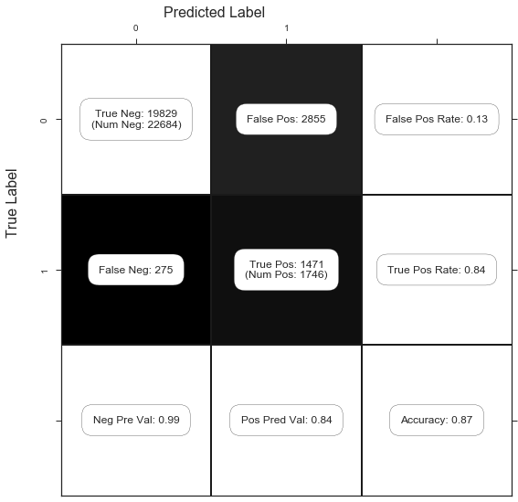

```
Optimization terminated successfully.    (Exit mode 0)
            Current function value: 0.154831150271
            Iterations: 508
            Function evaluations: 531
            Gradient evaluations: 508
```

```
'Iteration 2 : '
```

```
'Positive Prediction : 85.44 %'
```

```
'Actual Prediction : 86.65 %'
```

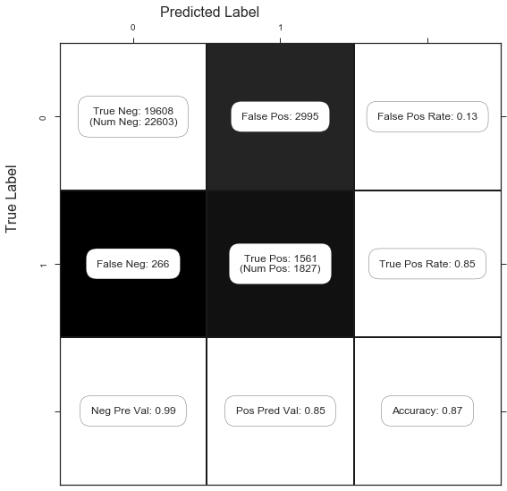

```
Optimization terminated successfully.    (Exit mode 0)
            Current function value: 0.154073122766
            Iterations: 481
            Function evaluations: 504
            Gradient evaluations: 481
```

```
'Iteration 3 : '
```

```
'Positive Prediction : 85.56 %'
```

```
'Actual Prediction : 85.9 %'
```

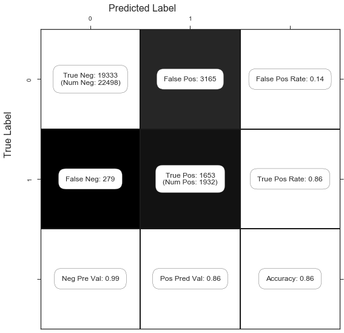

```
Optimization terminated successfully.    (Exit mode 0)
            Current function value: 0.153294144463
            Iterations: 480
            Function evaluations: 504
            Gradient evaluations: 480
```

```
'Iteration 4 : '
```

```
'Positive Prediction : 83.87 %'
```

```
'Actual Prediction : 85.86 %'
```

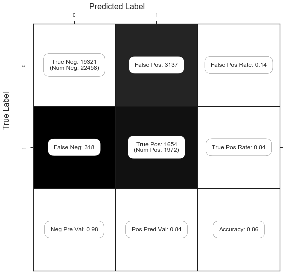

```
Optimization terminated successfully.    (Exit mode 0)
            Current function value: 0.154750285558
            Iterations: 496
            Function evaluations: 519
            Gradient evaluations: 496
```

```
'Iteration 5 : '
```

```
'Positive Prediction : 86.52 %'
```

```
'Actual Prediction : 86.43 %'
```

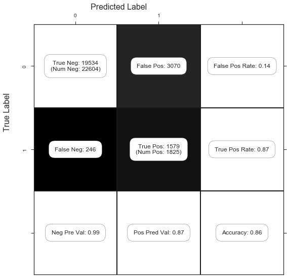

```
Optimization terminated successfully.    (Exit mode 0)
            Current function value: 0.154522219847
            Iterations: 470
            Function evaluations: 493
            Gradient evaluations: 470
```

```
'Iteration 6 : '
```

```
'Positive Prediction : 87.27 %'
```

```
'Actual Prediction : 85.89 %'
```

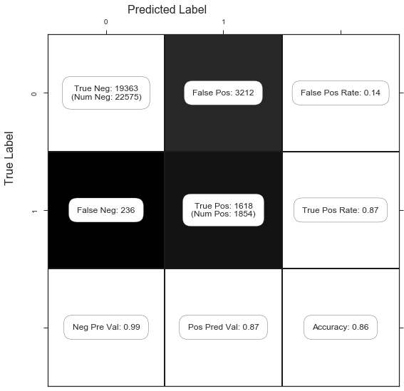

```
Optimization terminated successfully.    (Exit mode 0)
            Current function value: 0.154086168362
            Iterations: 509
            Function evaluations: 532
            Gradient evaluations: 509
```

```
'Iteration 7 : '
```

```
'Positive Prediction : 85.81 %'
```

```
'Actual Prediction : 84.82 %'
```

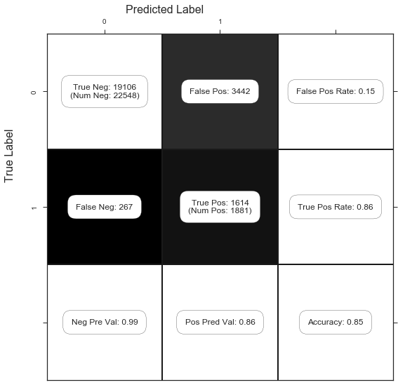

```
Optimization terminated successfully.    (Exit mode 0)
            Current function value: 0.154071045538
            Iterations: 510
            Function evaluations: 532
            Gradient evaluations: 510
```

```
'Iteration 8 : '
```

```
'Positive Prediction : 86.05 %'
```

```
'Actual Prediction : 85.73 %'
```

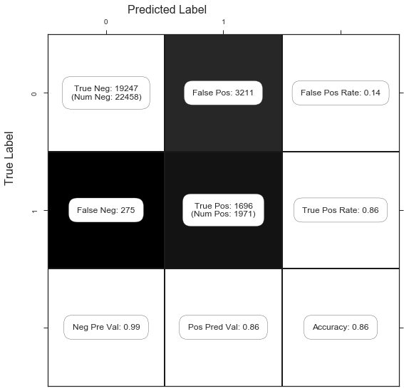

```
Optimization terminated successfully.    (Exit mode 0)
            Current function value: 0.153722746029
            Iterations: 491
            Function evaluations: 515
            Gradient evaluations: 491
```

```
'Iteration 9 : '
```

```
'Positive Prediction : 89.71 %'
```

```
'Actual Prediction : 84.24 %'
```

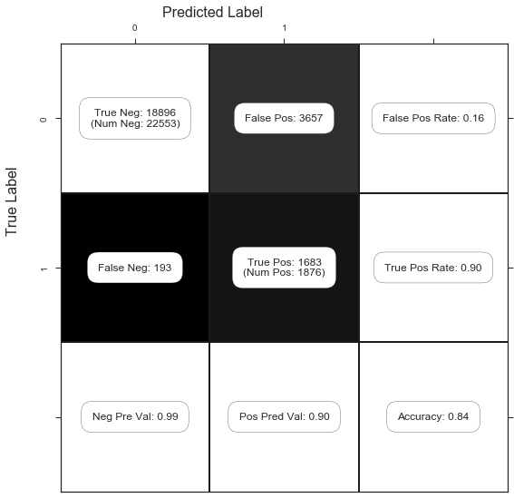

```
Optimization terminated successfully.    (Exit mode 0)
            Current function value: 0.155496344457
            Iterations: 506
            Function evaluations: 529
            Gradient evaluations: 506
```

```
'Iteration 10 : '
```

```
'Positive Prediction : 83.4 %'
```

```
'Actual Prediction : 87.08 %'
```

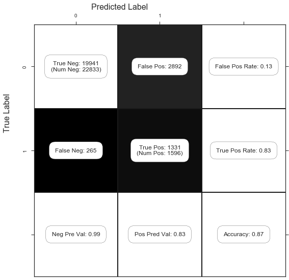

```python
mode.kcross()
```

### Distribution of deciles against % avoidability (KC - Curve)

```python
pr = mode.getprob()
```

```
Optimization terminated successfully.    (Exit mode 0)
            Current function value: 0.154447748978
            Iterations: 493
            Function evaluations: 517
            Gradient evaluations: 493
```

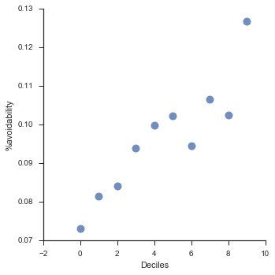

```python
bins = [0,0.1,0.2,0.3,0.4,0.5,0.6,0.7,0.8,0.9,1]
pr['capturemap'] = pd.cut(pr['probability'],bins,include_lowest = True)
clob = pr.groupby('capturemap').mean()
clob = clob.reset_index()
clob.index.names = ['decile']
clob = clob.reset_index()
clob.head(10)
sns.set_style("ticks")
sns.lmplot('decile', 'arma', data= clob, fit_reg=False,scatter_kws={"marker": "D", "s": 100})
plt.xlabel('Deciles')
plt.ylabel('%avoidability')
```

### ROC Curve

```python
inputs = mode.getROC()
```

```
Optimization terminated successfully.    (Exit mode 0)
            Current function value: 0.1553940571
            Iterations: 491
            Function evaluations: 515
            Gradient evaluations: 491
```

```python
def Find_Optimal_Cutoff(target, predicted):
    fpr, tpr, threshold = metrics.roc_curve(target, predicted)
    i = np.arange(len(tpr))
    roc = pd.DataFrame({'tf' : pd.Series(tpr-(1-fpr), index=i), 'threshold' : pd.Series(threshold, index=i)})
    roc_t = roc.ix[(roc.tf-0).abs().argsort()[:1]]

    return list(roc_t['threshold'])
```

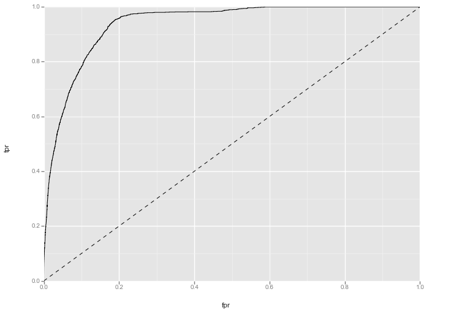

```python
fpr, tpr, _ = metrics.roc_curve(inputs['Actual'], inputs['Probability'])
df = pd.DataFrame(dict(fpr=fpr, tpr=tpr))
ggplot(df, aes(x='fpr', y='tpr')) +\
    geom_line() +\
    geom_abline(linetype='dashed')
```

```python
threshold = Find_Optimal_Cutoff(inputs['Actual'], inputs['Probability'])
```

```python
threshold
```

```
[0.094633833597938408]
```

Change the threshold to 0.095 for a maximum True positive rate and minimal False positive rate

### Testing

```python
TestData = variable.Gettestdata()
```

```python
TestData
```

|  | Incident_number | max_severity | engineer_cnt | wg_cnt | sr_reopened_cnt | pc_cnt | rc_cnt | bug_cnt | misqueue_cnt | initial_severity | ... | ntf_cases_cust | rt_cases_cust | sr_raised_cust | rma_rate_pid | ntf_cases_pid | rt_cases_pid | sr_raised_pid | bugs_pid | esc_flag_pm | arma |
| --- | --- | --- | --- | --- | --- | --- | --- | --- | --- | --- | --- | --- | --- | --- | --- | --- | --- | --- | --- | --- | --- |
| 0 | 632371959 | 3 | 1 | 1 | 0 | 2 | 0 | 0 | 1 | 3 | ... | 62.5 | 180.375 | 1493.5 | 606.625 | 16.625 | 70.625 | 2232.5 | 673 | 0 | 0 |
| 1 | 632371959 | 1 | 1 | 1 | 0 | 2 | 0 | 0 | 1 | 3 | ... | 62.5 | 180.375 | 1493.5 | 606.625 | 16.625 | 70.625 | 2232.5 | 673 | 0 | 0 |
| 2 | 632371959 | 1 | 2 | 2 | 0 | 2 | 0 | 0 | 1 | 3 | ... | 62.5 | 180.375 | 1493.5 | 606.625 | 16.625 | 70.625 | 2232.5 | 673 | 0 | 0 |
| 3 | 632371959 | 1 | 3 | 3 | 0 | 2 | 0 | 0 | 1 | 3 | ... | 62.5 | 180.375 | 1493.5 | 606.625 | 16.625 | 70.625 | 2232.5 | 673 | 0 | 0 |
| 4 | 632371959 | 1 | 4 | 4 | 0 | 2 | 0 | 0 | 1 | 3 | ... | 62.5 | 180.375 | 1493.5 | 606.625 | 16.625 | 70.625 | 2232.5 | 673 | 0 | 0 |

5 rows × 38 columns

```python
testmode = modelrun(TestData,var,varc)
testmode.createtestdummycolumns()
predicted = testmode.PredictTest(result,columns)
```

```python
predicted
```

```
array([ 0.14810084,  0.14810084,  0.41577097,  0.74445572,  0.92263319])
```

Risk score at various points in the SR journey.